# TidyTuesday Adventures

Author

Jo Hardin

The following each link to a different TidyTuesday analysis. Most of them are visualizations in R, but a few are models and a few are in Python. The link to this page is https://hardin47.github.io/TidyTuesday/.

A few other places to see TidyTuesday compilations:

- Steven Ponce [Data Visualizations](https://stevenponce.netlify.app/data_visualizations.html)
- Georgios Karamanis [TidyTuesday](https://karaman.is/) gallery.
- Nicola Rennie [#TidyTuesday](https://github.com/nrennie/tidytuesday). Also, check our her [data science resources](https://nrennie.rbind.io/data-science-resources/). And she has now created a [Data Visualization Gallery](https://nrennie.rbind.io/viz-gallery/).
- Carl Börstell [tidytuesday](https://github.com/borstell/tidytuesday/tree/main)
- Rajo [TidyTuesday](https://github.com/rajodm/TidyTuesday/)
- Manish Datt [Visualization of various datasets using Python, R and Javascript](https://dataviz.manishdatt.com/)

## 2026

- 2026-08-12 [Foundation Shades](https://hardin47.github.io/TidyTuesday/2026-08-12/makeup_shades.html)

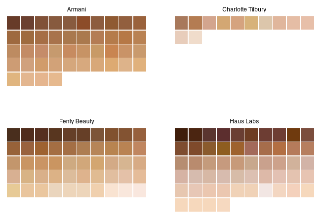

- 2026-08-06 [Market Indices](https://hardin47.github.io/TidyTuesday/2026-08-06/market_index.html)

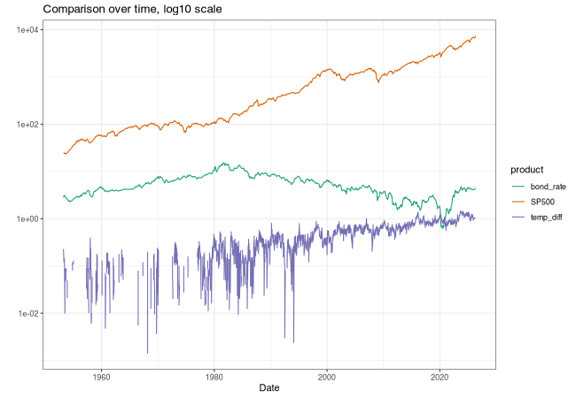

- 2026-07-23 [Love Island USA](https://hardin47.github.io/TidyTuesday/2026-07-23/loveisland.html)

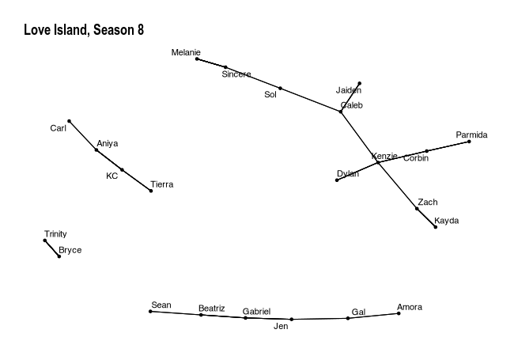

- 2026-06-30 [Shipwrecks in Ireland](https://hardin47.github.io/TidyTuesday/2026-06-30/shipwreck.html)

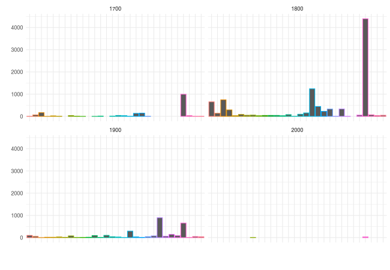

- 2026-06-16 [UK Babynames](https://hardin47.github.io/TidyTuesday/2026-06-16/UKbabynames.html)

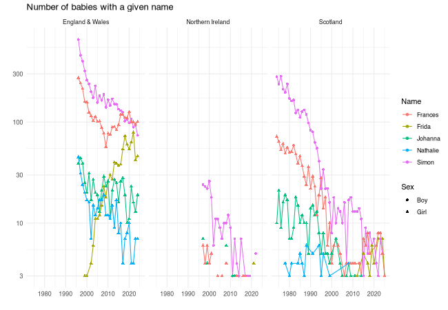

- 2026-06-02 [European Parenting Leave Policies](https://hardin47.github.io/TidyTuesday/2026-06-02/parenting.html)

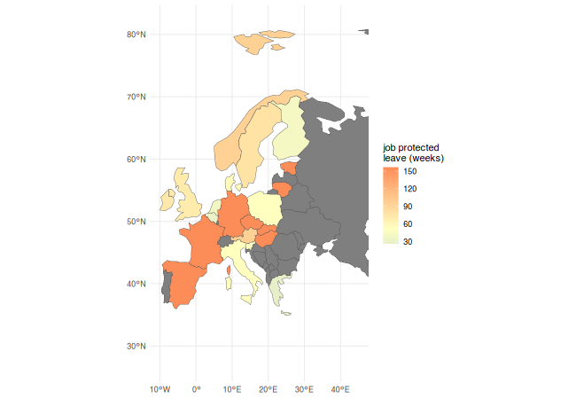

- 2026-05-05 [Italian industrial production](https://hardin47.github.io/TidyTuesday/2026-05-05/italian_production.html)

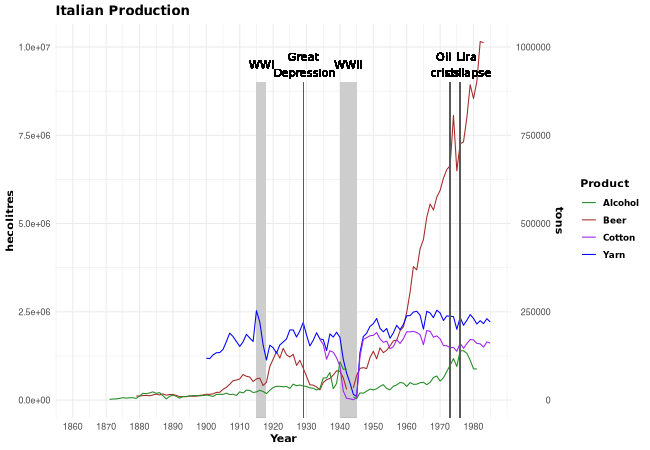

- 2026-04-21 [Global Health Spending](https://hardin47.github.io/TidyTuesday/2026-04-21/globalhealth.html)

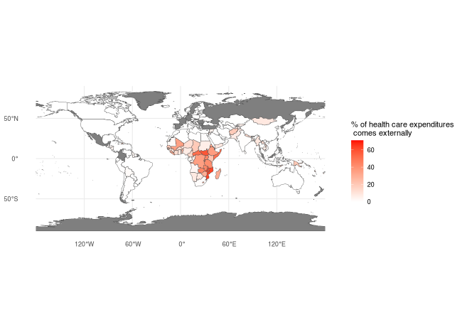

- 2026-04-14 [Bird Sightings](https://hardin47.github.io/TidyTuesday/2026-04-14/birds.html)

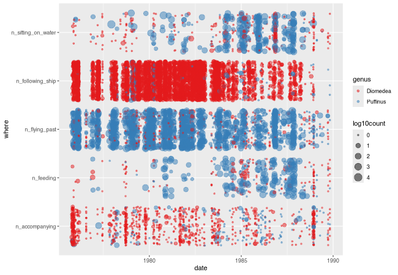

- 2026-04-07 [Repair Cafe](https://hardin47.github.io/TidyTuesday/2026-04-07/repair.html)

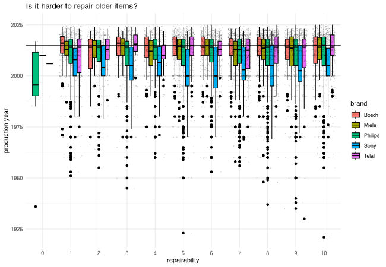

- 2026-03-24 [Digits of pi](https://hardin47.github.io/TidyTuesday/2026-03-24/pi_digits.html)

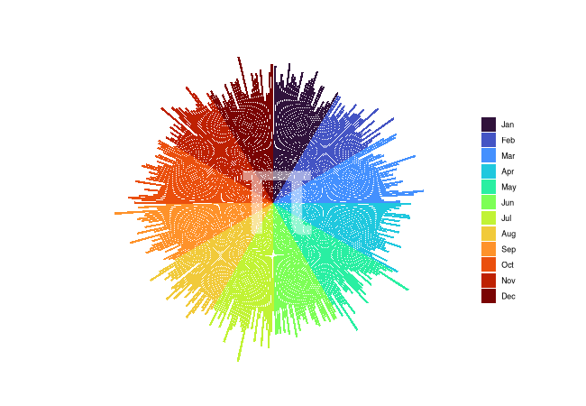

- 2026-03-10 [How likely is ‘likely’?](https://hardin47.github.io/TidyTuesday/2026-03-10/likely.html)

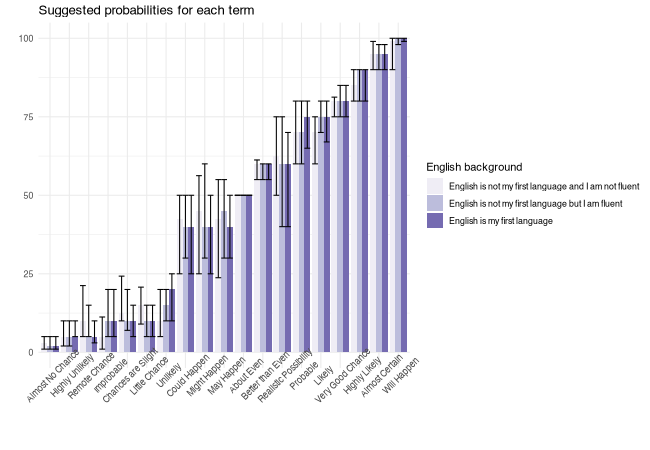

- 2026-03-03 [Hermann’s Tortoises](https://hardin47.github.io/TidyTuesday/2026-03-03/tortoises.html)

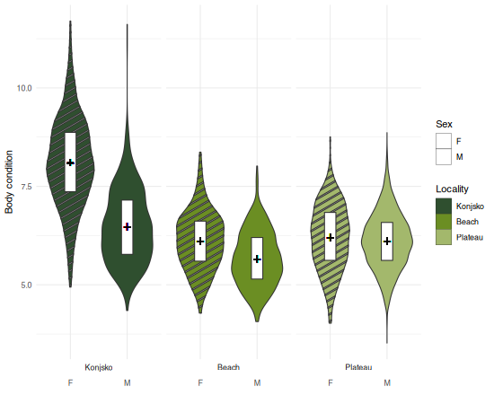

- 2026-02-24 [Science Foundation Ireland Grants Commitments](https://hardin47.github.io/TidyTuesday/2026-02-24/sfi.html)

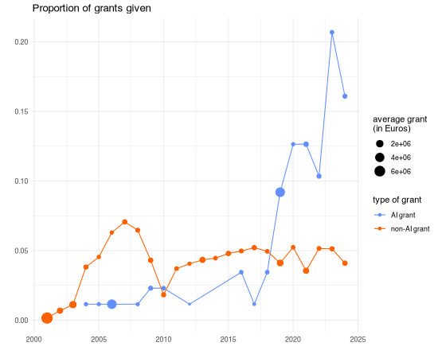

- 2026-02-17 [New Zealand Agriculture](https://hardin47.github.io/TidyTuesday/2026-02-17/nz_agriculture.html)

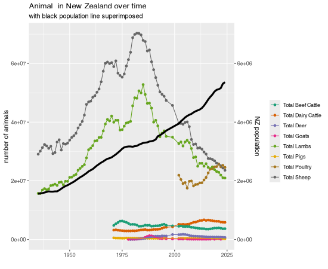

- 2026-02-10 [Winter Olympics](https://hardin47.github.io/TidyTuesday/2026-02-10/winterolympics.html)

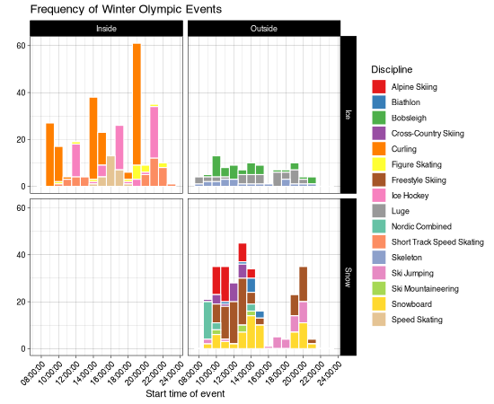

- 2026-02-03 [Edible Plants](https://hardin47.github.io/TidyTuesday/2026-02-03/edibleplants.html)

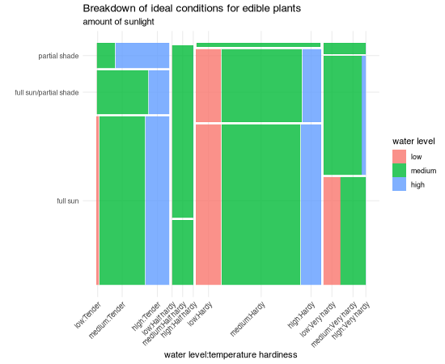

- 2026-01-27 [Brazilian Companies](https://hardin47.github.io/TidyTuesday/2026-01-27/Brazil_co.html)

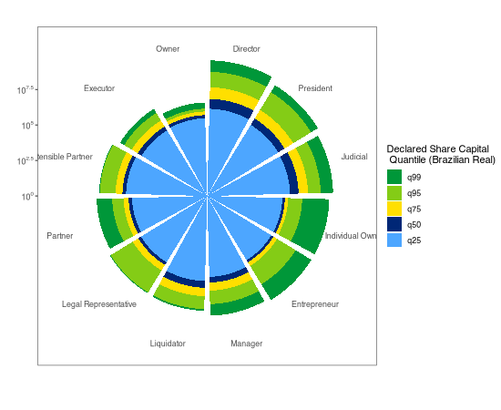

## 2025

- 2025-12-02 [Sechselaeuten spring festival](https://hardin47.github.io/TidyTuesday/2025-12-02/snowman.html)

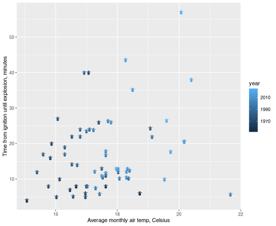

- 2025-11-18 [The Complete Sherlock Holmes](https://hardin47.github.io/TidyTuesday/2025-11-18/holmes.html)

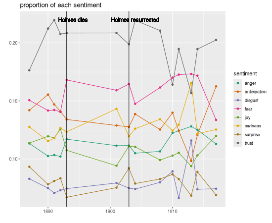

- 2025-11-11 [WHO TB burden data](https://hardin47.github.io/TidyTuesday/2025-11-11/who.html)

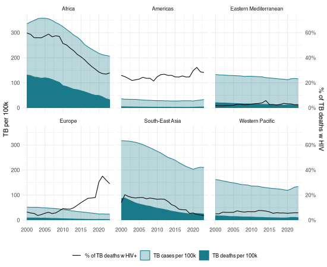

- 2025-11-04 [Lead concentration in Flint water samples in 2015 (scrollytelling)](https://hardin47.github.io/TidyTuesday/2025-11-04/flint.html)

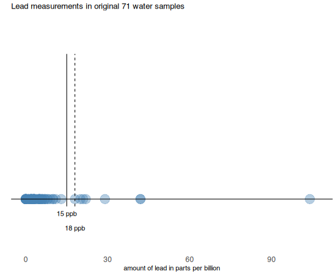

- 2025-10-28 [Selected British Literary Prizes](https://hardin47.github.io/TidyTuesday/2025-10-28/literary_prize.html)

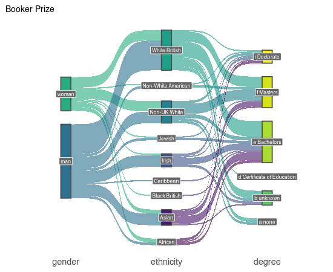

- 2025-10-21 [UK Meteorological & Climate Data](https://hardin47.github.io/TidyTuesday/2025-10-21/climate.html)

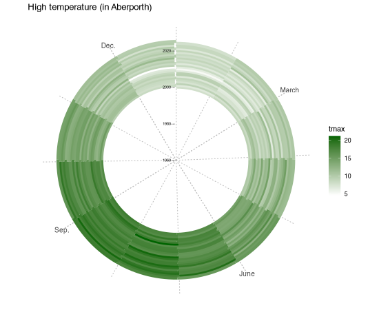

- 2025-10-07 [EuroLeague Basketball](https://hardin47.github.io/TidyTuesday/2025-10-07/euroleague.html)

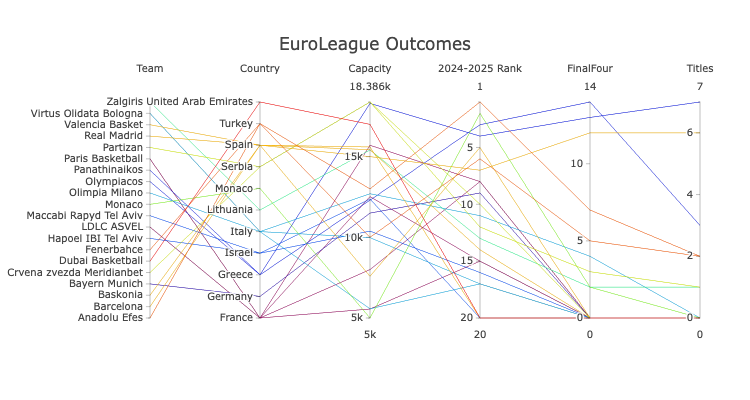

- 2025-09-30 [Crane Observations at Lake Hornborgasjön, Sweden](https://hardin47.github.io/TidyTuesday/2025-09-30/cranes.html)

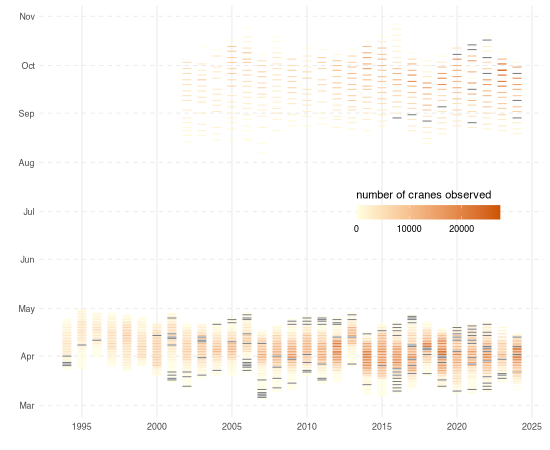

- 2025-09-23 [FIDE Chess Player Ratings](https://hardin47.github.io/TidyTuesday/2025-09-23/chess.html)

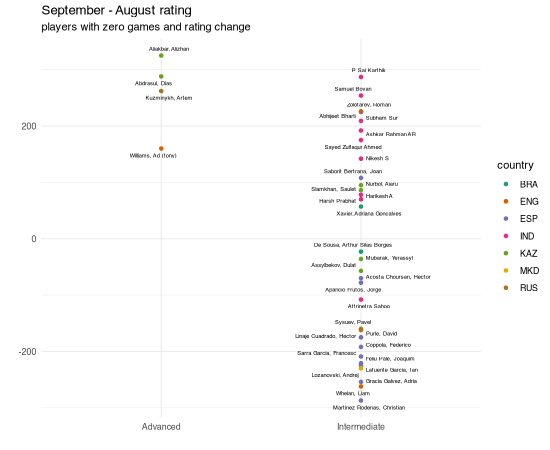

- 2025-09-16 [Allrecipies](https://hardin47.github.io/TidyTuesday/2025-09-16/allrecipes.html)

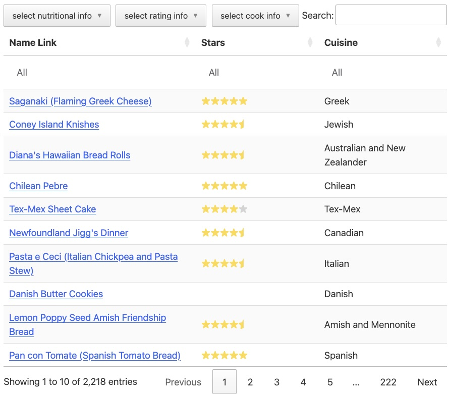

- 2025-09-09 [Henley Passport Index](https://hardin47.github.io/TidyTuesday/2025-09-09/passports.html)

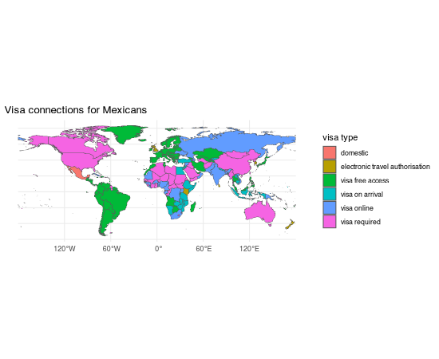

- 2025-09-02 [Australian frogs](https://hardin47.github.io/TidyTuesday/2025-09-02/frogs.html)

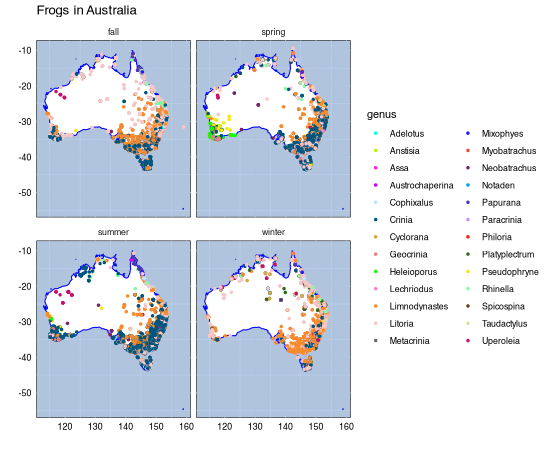

- 2025-07-08 [xkcd Color Survey](https://hardin47.github.io/TidyTuesday/2025-07-08/xkcd_color.html)